# Priced Out Twice: How Home Prices and Mortgage Rates Reshaped U.S. Affordability

A FRED-based decomposition of the 2019–2025 homebuying squeeze

housing

data-visualization

FRED

Home prices rose first, mortgage rates then intensified the squeeze, and income growth only partly restored purchasing power.

Published

October 5, 2026

## The question: what changed after 2019?

A house can become less affordable in three ways: its price rises, the mortgage rate rises, or household income fails to keep up. Since 2019, all three have moved at different times. Which changes mattered most for a typical prospective buyer?

I combine five public series downloaded programmatically from the Federal Reserve Bank of St. Louis’s FRED service. They measure the median price of a **new** home, the average 30-year fixed mortgage rate, median household income, consumer prices, and NBER recession periods. The analysis ends in 2025 Q4, the latest quarter for which all required series overlap.

The central measure is an illustrative mortgage burden. I assume a 20% down payment and a 30-year fixed-rate loan. For house price (P), annual mortgage rate (i), and monthly rate (r=i/12), the monthly principal-and-interest payment is

$$M=0.8P\frac{r(1+r)^{360}}{(1+r)^{360}-1}.$$

I then divide (12M) by annual median household income. This is a transparent comparison, not a claim that the median household purchases the median new home.

## Prices outran income over the longer run

First, I adjust both prices and income for inflation using CPI and index each series to 100 in 2000 Q1. This compares growth rates without mixing dollars measured in different years.

**Show reproducible R code**

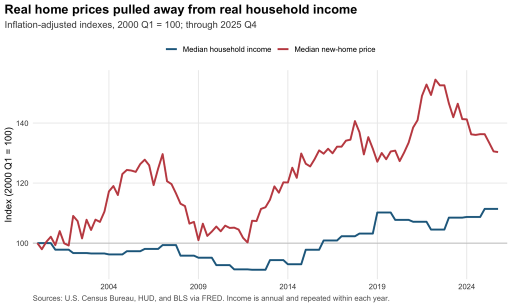

Figure 1: Inflation-adjusted median new-home prices and median household income, indexed to 2000 Q1.

```r
fig1
```

By 2025 Q4, the real new-home-price index was 130, while real median income was 111. The gap was not smooth: prices surged after 2020, while income adjusted more gradually. This longer-run divergence explains why the down payment and loan principal became larger relative to household resources.

## Financing costs delivered a second shock

The payment calculation translates prices and rates into the cash flow a buyer would face. Grey bands mark recessions.

**Show reproducible R code**

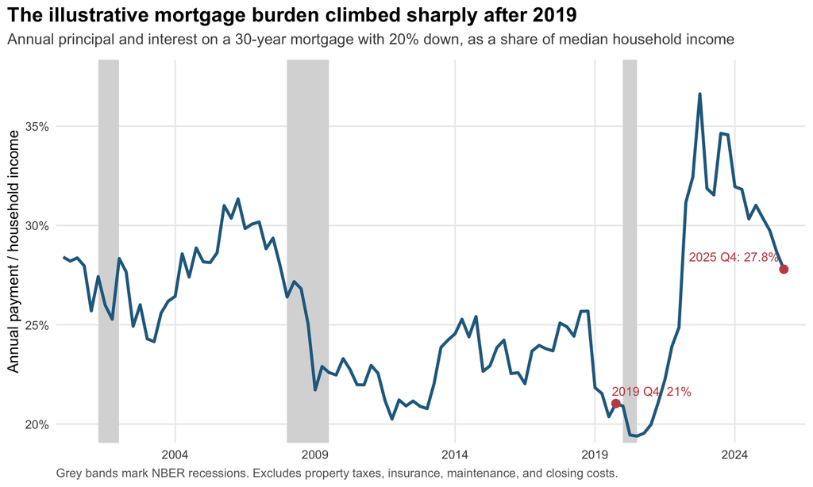

Figure 2: Illustrative annual mortgage payments as a share of median household income.

```r
fig2
```

## Separating price, rate, and income changes

A sequential counterfactual clarifies the arithmetic. Starting from 2019 Q4, I first substitute the 2025 home price, then the 2025 mortgage rate, and finally the 2025 household income.

**Show reproducible R code**

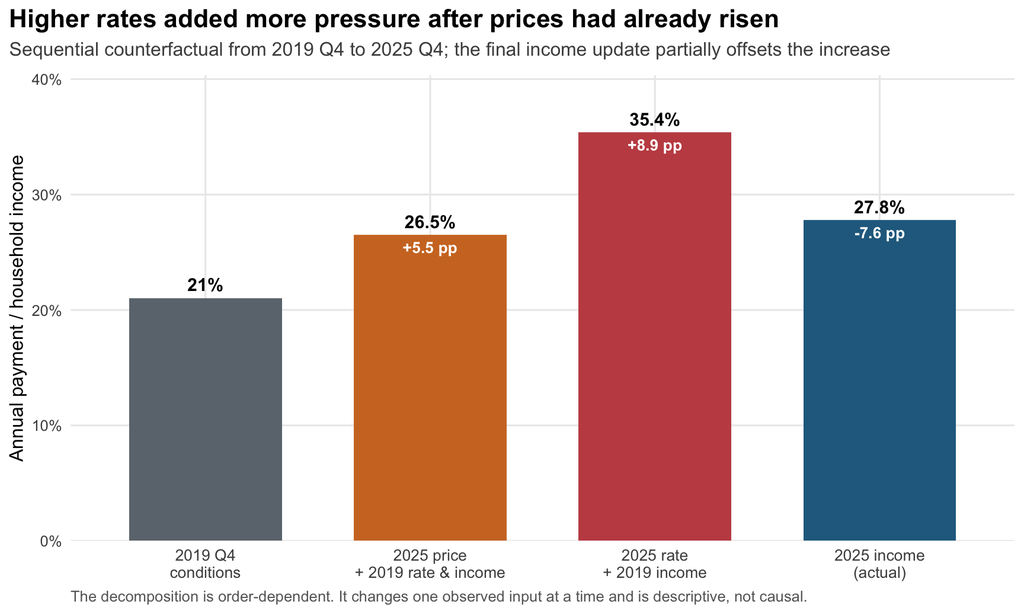

Figure 3: Sequential decomposition of the change in the illustrative mortgage-payment burden.

```r
fig3
```

The higher home price adds 5.5 percentage points. Updating the mortgage rate from 3.70% to 6.23% adds another 8.9 points. Updating income from $68,700 to $87,460 then removes 7.6 points. The order matters because price and rate interact in the payment formula, so this is a descriptive decomposition rather than a causal estimate. Still, it reveals why looking only at prices misses much of the post-2021 squeeze.

**Show reproducible R code**

```r
knitr::kable(
  key_years,
  col.names = c("Quarter", "Median new-home price ($)",
                "Mortgage rate (%)", "Median household income ($)",
                "Annual payment / income (%)"),
  format.args = list(big.mark = ",")
)
```

Selected fourth-quarter inputs and the resulting illustrative burden.

[output not shown]

## Sources, limitations, and takeaway

The raw CSV files were retrieved on October 5, 2026 through FRED’s public graph endpoint. The underlying sources are the [U.S. Census Bureau and HUD for new-home prices](https://fred.stlouisfed.org/series/MSPUS), [Freddie Mac for mortgage rates](https://fred.stlouisfed.org/series/MORTGAGE30US), the [Census Bureau for household income](https://fred.stlouisfed.org/series/MEHOINUSA646N), the [Bureau of Labor Statistics for CPI](https://fred.stlouisfed.org/series/CPIAUCSL), and [FRED’s NBER-based recession indicator](https://fred.stlouisfed.org/series/USRECQ). The complete code, raw data, cleaned dataframe, and exported figures are in the [project repository](https://github.com/haozhuo22/blog-post-4-housing-affordability).

This national comparison omits regional variation, existing homes, taxes, insurance, maintenance, credit constraints, and the difficulty of accumulating a down payment. It also combines a median home with a median household rather than tracking the same buyers.

**NoteTakeaway**

The affordability squeeze arrived in two stages: home prices raised the amount that had to be financed, and higher mortgage rates made each borrowed dollar more expensive. Income growth offset part of the damage by 2025, but did not restore the 2019 payment burden.